# Lecture 07 playground

```r
library(tidyverse)
library(patchwork)
library(emmeans)
library(simglm)
```

# Sum-code `study` (two levels)

### Group means

```r
test_study3 |>
  group_by(study) |>
  summarise(
    avg_score = round(mean(score), 2)
  )
```

| study | avg_score |
| --- | --- |
| alone | 22.8 |
| others | 27.5 |

```r
mean_alone <- filter(test_study3, study == 'alone')$score |> mean()
mean_others <- filter(test_study3, study == 'others')$score |> mean()
```

## Define sum coding

```r
contrasts(test_study3$study) <- contr.sum( levels(test_study3$study) )
contrasts(test_study3$study)
```

```
       [,1]
alone     1
others   -1
```

## Plot on xy plane

pm1 effect coding:

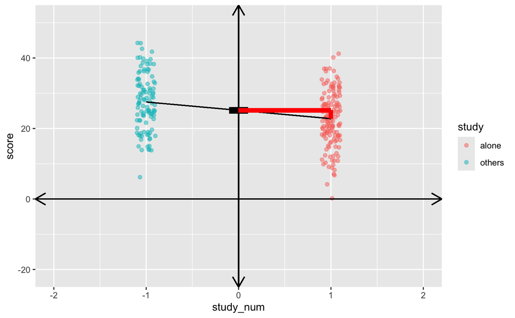

```r
xlim_lower <- -2.2
xlim_upper <-  2.2
ylim_lower <- -25
ylim_upper <-  55

grand_mean <- mean(c(mean_alone, mean_others))

test_study3 |>
  mutate(study_num = ifelse(study == 'alone', 1, -1)) |>
  ggplot(aes(x = study_num, y = score, fill = study, colour = study)) +
  geom_jitter(alpha = 0.5, width = 0.1) +
  scale_x_continuous(limits = c(xlim_lower, xlim_upper), expand = c(0, 0)) +
  scale_y_continuous(limits = c(ylim_lower, ylim_upper), expand = c(0, 0)) +
  geom_segment(aes(x = xlim_lower, xend = xlim_upper, y = 0, yend = 0), arrow = arrow(ends = 'both', length = unit(12, 'pt')), colour = 'black') +
  geom_segment(aes(x = 0, xend = 0, y = ylim_lower, yend = ylim_upper), arrow = arrow(ends = 'both', length = unit(12, 'pt')), colour = 'black') +
  geom_segment(aes(x = -1, xend = 1, y = mean_others, yend = mean_alone), colour = 'black') +
  geom_segment(aes(x = -.1, xend = .1, y = grand_mean, yend = grand_mean), colour = 'black', linewidth = 3) +
  geom_segment(aes(x = 0, xend = 1, y = grand_mean, yend = grand_mean), colour = 'red', linewidth = 2) +
  geom_segment(aes(x = 1, xend = 1, y = grand_mean, yend = mean_alone), colour = 'red', linewidth = 2) +
  NULL
```

## Model `score ~ study`

```r
mod1 <- lm(score ~ study, data = test_study3)
summary(mod1)
```

```
Call:
lm(formula = score ~ study, data = test_study3)

Residuals:
     Min       1Q   Median       3Q      Max
-22.7902  -4.7902   0.2098   5.4766  18.2098

Coefficients:
            Estimate Std. Error t value Pr(>|t|)
(Intercept)  25.1568     0.5047   49.85  < 2e-16 ***
study1       -2.3666     0.5047   -4.69 4.53e-06 ***
---
Signif. codes:  0 ‘***’ 0.001 ‘**’ 0.01 ‘*’ 0.05 ‘.’ 0.1 ‘ ’ 1

Residual standard error: 7.896 on 248 degrees of freedom
Multiple R-squared:  0.08145,   Adjusted R-squared:  0.07775
F-statistic: 21.99 on 1 and 248 DF,  p-value: 4.525e-06
```

- Intercept = grand mean

```r
mean(c(mean_alone, mean_others))
```

```
[1] 25.15679
```

- slope = 1/2 of the difference between the two groups = difference between whatever group is coded as 1 which here is `alone` and the grand mean
- the first part of this interpretation is specific to the two-group case!

```r
(mean_alone - mean_others) / 2
```

```
[1] -2.366577
```

```r
mean_alone - grand_mean
```

```
[1] -2.366577
```

Aside: Why is grand mean != mean of all scores? Because the grand mean is the mean of means, whereas the mean of all scores takes into acct that some groups are unevenly sized.

```r
mean(test_study3$score)
```

```
[1] 24.816
```

# Sum-code `method` (three levels)

## Group means

```r
test_study3 |>
  group_by(method) |>
  summarise(
    avg_score = round(mean(score), 2)
  )
```

| method | avg_score |
| --- | --- |
| read | 23.4 |
| self-test | 27.6 |
| summarise | 24.2 |

```r
mean_read <- filter(test_study3, method == 'read')$score |> mean()
mean_self <- filter(test_study3, method == 'self-test')$score |> mean()
mean_summ <- filter(test_study3, method == 'summarise')$score |> mean()

methods_grand_mean <- mean(c(mean_read, mean_self, mean_summ))
```

## Define sum coding

```r
contrasts(test_study3$method) <- contr.sum( levels(test_study3$method) )
contrasts(test_study3$method)
```

```
          [,1] [,2]
read         1    0
self-test    0    1
summarise   -1   -1
```

## Plot on xy plane

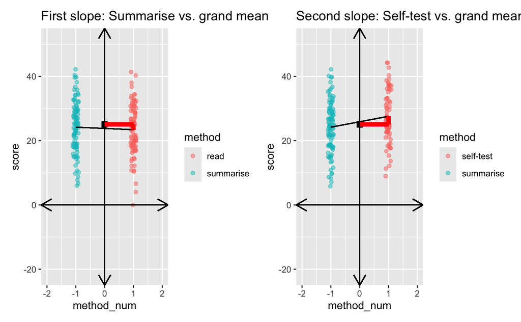

```r
xlim_lower <- -2.2
xlim_upper <-  2.2
ylim_lower <- -25
ylim_upper <-  55

# mean_summread <- mean(c(mean_summ, mean_read))
# mean_summself <- mean(c(mean_summ, mean_self))


p1 <- test_study3 |>
  filter(method %in% c('summarise', 'read')) |>
  mutate(method_num = ifelse(method == 'summarise', -1, 1)) |>
  ggplot(aes(x = method_num, y = score, fill = method, colour = method)) +
  geom_jitter(alpha = 0.5, width = 0.1) +
  scale_x_continuous(limits = c(xlim_lower, xlim_upper), expand = c(0, 0)) +
  scale_y_continuous(limits = c(ylim_lower, ylim_upper), expand = c(0, 0)) +
  geom_segment(aes(x = xlim_lower, xend = xlim_upper, y = 0, yend = 0), arrow = arrow(ends = 'both', length = unit(12, 'pt')), colour = 'black') +
  geom_segment(aes(x = 0, xend = 0, y = ylim_lower, yend = ylim_upper), arrow = arrow(ends = 'both', length = unit(12, 'pt')), colour = 'black') +
  geom_segment(aes(x = -.1, xend = .1, y = methods_grand_mean, yend = methods_grand_mean), colour = 'black', linewidth = 3) +
  geom_segment(aes(x = -1, xend = 1, y = mean_summ, yend = mean_read), colour = 'black') +
  geom_segment(aes(x = 0, xend = 1, y = methods_grand_mean, yend = methods_grand_mean), colour = 'red', linewidth = 2) +
  geom_segment(aes(x = 1, xend = 1, y = methods_grand_mean, yend = mean_read), colour = 'red', linewidth = 2) +
  labs(
    title = 'First slope: Summarise vs. grand mean'
  ) +
  NULL

p2 <- test_study3 |>
  filter(method %in% c('summarise', 'self-test')) |>
  mutate(method_num = ifelse(method == 'summarise', -1, 1)) |>
  ggplot(aes(x = method_num, y = score, fill = method, colour = method)) +
  geom_jitter(alpha = 0.5, width = 0.1) +
  scale_x_continuous(limits = c(xlim_lower, xlim_upper), expand = c(0, 0)) +
  scale_y_continuous(limits = c(ylim_lower, ylim_upper), expand = c(0, 0)) +
  geom_segment(aes(x = xlim_lower, xend = xlim_upper, y = 0, yend = 0), arrow = arrow(ends = 'both', length = unit(12, 'pt')), colour = 'black') +
  geom_segment(aes(x = 0, xend = 0, y = ylim_lower, yend = ylim_upper), arrow = arrow(ends = 'both', length = unit(12, 'pt')), colour = 'black') +
  geom_segment(aes(x = -.1, xend = .1, y = methods_grand_mean, yend = methods_grand_mean), colour = 'black', linewidth = 3) +
  geom_segment(aes(x = -1, xend = 1, y = mean_summ, yend = mean_self), colour = 'black') +
  geom_segment(aes(x = 0, xend = 1, y = methods_grand_mean, yend = methods_grand_mean), colour = 'red', linewidth = 2) +
  geom_segment(aes(x = 1, xend = 1, y = methods_grand_mean, yend = mean_self), colour = 'red', linewidth = 2) +
  labs(
    title = 'Second slope: Self-test vs. grand mean'
  ) +
  NULL

p1 + p2
```

This visualisation is no longer super useful because our contrasts end up leaving out some of the data. In other words, the grand mean doesn’t live anywhere obvious on this plot, because some of the data is left out.

## Model `score ~ method`

```r
contrasts(test_study3$method)
```

```
          [,1] [,2]
read         1    0
self-test    0    1
summarise   -1   -1
```

```r
mod2 <- lm(score ~ method, data = test_study3)
summary(mod2)
```

```
Call:
lm(formula = score ~ method, data = test_study3)

Residuals:
     Min       1Q   Median       3Q      Max
-23.4138  -5.3593  -0.1959   5.7496  17.8041

Coefficients:
            Estimate Std. Error t value Pr(>|t|)
(Intercept)  25.0618     0.5177  48.409  < 2e-16 ***
method1      -1.6480     0.7198  -2.290  0.02289 *
method2       2.5139     0.7731   3.252  0.00131 **
---
Signif. codes:  0 ‘***’ 0.001 ‘**’ 0.01 ‘*’ 0.05 ‘.’ 0.1 ‘ ’ 1

Residual standard error: 8.079 on 247 degrees of freedom
Multiple R-squared:  0.04224,   Adjusted R-squared:  0.03448
F-statistic: 5.447 on 2 and 247 DF,  p-value: 0.004845
```

```r
mean_read - methods_grand_mean
```

```
[1] -1.648016
```

```r
mean_self - methods_grand_mean
```

```
[1] 2.513949
```

## emmeans

```r
(mod2_emm <- emmeans(mod2, ~method))
```

```
 method    emmean    SE  df lower.CL upper.CL
 read        23.4 0.866 247     21.7     25.1
 self-test   27.6 0.994 247     25.6     29.5
 summarise   24.2 0.820 247     22.6     25.8

Confidence level used: 0.95
```

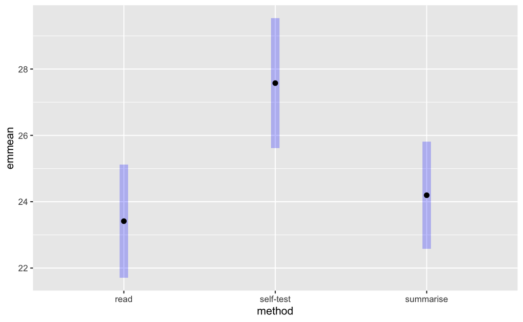

```r
mod2_emm |> plot() +
  coord_flip()
```

```r
levels(test_study3$method)
```

```
[1] "read"      "self-test" "summarise"
```

```r
mod2_comparisons <- list(
  'Self-test vs. Read' = c(-1, 1, 0),  # read self-test summarise, in that order
  'Summarise vs. Read' = c(-1, 0, 1),
  'Self-test vs. Summarise' = c(0, 1, -1),
  'mean(Self-test, summarise) vs. Read' = c(-1, 0.5, 0.5)  # weights must sum to 0 -- pools self-test and summarise tog and pits that mean against mean of Read
)

(mod2_comparisons_test <- contrast(mod2_emm, mod2_comparisons))
```

```
 contrast                            estimate   SE  df t.ratio p.value
 Self-test vs. Read                     4.162 1.32 247   3.156  0.0018
 Summarise vs. Read                     0.782 1.19 247   0.656  0.5127
 Self-test vs. Summarise                3.380 1.29 247   2.622  0.0093
 mean(Self-test, summarise) vs. Read    2.472 1.08 247   2.290  0.0229
```

```r
confint(mod2_comparisons_test)
```

```
 contrast                            estimate   SE  df lower.CL upper.CL
 Self-test vs. Read                     4.162 1.32 247    1.564     6.76
 Summarise vs. Read                     0.782 1.19 247   -1.568     3.13
 Self-test vs. Summarise                3.380 1.29 247    0.841     5.92
 mean(Self-test, summarise) vs. Read    2.472 1.08 247    0.345     4.60

Confidence level used: 0.95
```

## TODO: trtmt code model, use emmeans to test sum contrasts

```r
contrasts(test_study3$method) <- contr.treatment(levels(test_study3$method))
contrasts(test_study3$method)
```

```
          self-test summarise
read              0         0
self-test         1         0
summarise         0         1
```

```r
mod2b <- lm(score ~ method, data = test_study3)
summary(mod2b)
```

```
Call:
lm(formula = score ~ method, data = test_study3)

Residuals:
     Min       1Q   Median       3Q      Max
-23.4138  -5.3593  -0.1959   5.7496  17.8041

Coefficients:
                Estimate Std. Error t value Pr(>|t|)
(Intercept)      23.4138     0.8662  27.031   <2e-16 ***
methodself-test   4.1620     1.3188   3.156   0.0018 **
methodsummarise   0.7821     1.1930   0.656   0.5127
---
Signif. codes:  0 ‘***’ 0.001 ‘**’ 0.01 ‘*’ 0.05 ‘.’ 0.1 ‘ ’ 1

Residual standard error: 8.079 on 247 degrees of freedom
Multiple R-squared:  0.04224,   Adjusted R-squared:  0.03448
F-statistic: 5.447 on 2 and 247 DF,  p-value: 0.004845
```

```r
mod2b_emm <- emmeans(mod2b, ~method)
```

Use the same comparisons as above.

```r
(mod2b_comparisons_test <- contrast(mod2b_emm, mod2_comparisons))
```

```
 contrast                            estimate   SE  df t.ratio p.value
 Self-test vs. Read                     4.162 1.32 247   3.156  0.0018
 Summarise vs. Read                     0.782 1.19 247   0.656  0.5127
 Self-test vs. Summarise                3.380 1.29 247   2.622  0.0093
 mean(Self-test, summarise) vs. Read    2.472 1.08 247   2.290  0.0229
```

Yes, it’s exactly the same.

# DIY contrasts

Simulate the data for subjective well-being based on partnership.

```r
n <- round(500*(c(.55, .2, .1, .05, .1)),0)
set.seed(7284)
wb_tib <- tibble(
  swb = c(rnorm(n[1], 11, 3.6),
          rnorm(n[2], 12, 4.2),
          rnorm(n[3], 8, 2.2),
          rnorm(n[4], 6, 1.1),
          rnorm(n[5], 9.5, 2.5)),
  status = factor(c(rep("Married/CP", n[1]),
             rep("Cohab", n[2]),
             rep("Single", n[3]),
             rep("Widowed", n[4]),
             rep("Divorced", n[5]))
             )
)
```

```r
wb_tib
```

| swb | status |
| --- | --- |
| 14.2436 | Married/CP |
| 10.5144 | Married/CP |
| 7.7442 | Married/CP |
| 11.5267 | Married/CP |
| 15.2306 | Married/CP |
| 13.4878 | Married/CP |
| 13.8198 | Married/CP |
| 4.9217 | Married/CP |
| 11.8181 | Married/CP |
| 11.9825 | Married/CP |

[output cut: 490 more lines]

## Treatment-coded, manual contrasts in emmeans post-hoc

```r
contrasts(wb_tib$status)
```

```
           Divorced Married/CP Single Widowed
Cohab             0          0      0       0
Divorced          1          0      0       0
Married/CP        0          1      0       0
Single            0          0      1       0
Widowed           0          0      0       1
```

```r
mod3 <- lm(swb ~ status, wb_tib)
summary(mod3)
```

```
Call:
lm(formula = swb ~ status, data = wb_tib)

Residuals:
     Min       1Q   Median       3Q      Max
-11.3373  -2.0776  -0.0019   2.0535  11.4730

Coefficients:
                 Estimate Std. Error t value Pr(>|t|)
(Intercept)       11.4375     0.3330  34.348  < 2e-16 ***
statusDivorced    -2.0643     0.5768  -3.579 0.000379 ***
statusMarried/CP  -0.8124     0.3889  -2.089 0.037208 *
statusSingle      -3.3773     0.5768  -5.856 8.66e-09 ***
statusWidowed     -5.4328     0.7446  -7.296 1.18e-12 ***
---
Signif. codes:  0 ‘***’ 0.001 ‘**’ 0.01 ‘*’ 0.05 ‘.’ 0.1 ‘ ’ 1

Residual standard error: 3.33 on 495 degrees of freedom
Multiple R-squared:  0.1416,    Adjusted R-squared:  0.1347
F-statistic: 20.42 on 4 and 495 DF,  p-value: 1.383e-15
```

```r
mod3_emm <- emmeans(mod3, ~status)
mod3_emm
```

```
 status     emmean    SE  df lower.CL upper.CL
 Cohab       11.44 0.333 495    10.78    12.09
 Divorced     9.37 0.471 495     8.45    10.30
 Married/CP  10.63 0.201 495    10.23    11.02
 Single       8.06 0.471 495     7.13     8.99
 Widowed      6.00 0.666 495     4.70     7.31

Confidence level used: 0.95
```

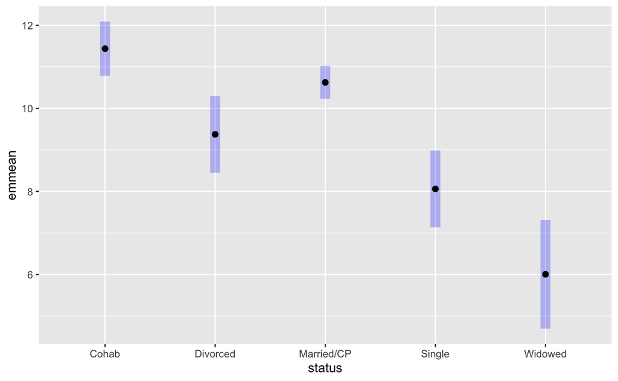

```r
plot(mod3_emm) +
  coord_flip()
```

### Test manual contrasts

```r
mod3_comparison <- list(
  "Married or CP vs not" = c(-1/2, 1/3, 1/3, -1/2, 1/3),
  "Current vs Not current" = c(0, -1/2, 1, 0, -1/2)
)

(mod3_contrasts <- contrast(mod3_emm, mod3_comparison))
```

```
 contrast               estimate    SE  df t.ratio p.value
 Married or CP vs not      -1.08 0.402 495  -2.690  0.0074
 Current vs Not current     2.94 0.455 495   6.459  <.0001
```

```r
(mod3_confint <- confint(mod3_contrasts))
```

```
 contrast               estimate    SE  df lower.CL upper.CL
 Married or CP vs not      -1.08 0.402 495    -1.87   -0.291
 Current vs Not current     2.94 0.455 495     2.04    3.829

Confidence level used: 0.95
```

## Custom a priori contrasts?

Construct a matrix that contains the contrasts we want.

```r
custom_contrast_mtx <- matrix(
  c(
    -1/2, 1/3, 1/3, -1/2, 1/3,
    0, -1/2, 1, 0, -1
  ),
  ncol = 2
)

rownames(custom_contrast_mtx) <- levels(wb_tib$status)
custom_contrast_mtx
```

```
                 [,1] [,2]
Cohab      -0.5000000  0.0
Divorced    0.3333333 -0.5
Married/CP  0.3333333  1.0
Single     -0.5000000  0.0
Widowed     0.3333333 -1.0
```

```r
contrasts(wb_tib$status) <- custom_contrast_mtx  # only overwrites first two cols
contrasts(wb_tib$status)
```

```
                 [,1] [,2]        [,3]       [,4]
Cohab      -0.5000000  0.0 -0.69562405 -0.1269141
Divorced    0.3333333 -0.5  0.14079854 -0.7717256
Married/CP  0.3333333  1.0 -0.03519964  0.1929314
Single     -0.5000000  0.0  0.69562405  0.1269141
Widowed     0.3333333 -1.0 -0.10559891  0.5787942
```

Columns 3 and 4 will be necessary for balancing the hypothesis/contrast matrix. So that makes this an overly complicated example for the lectures. Best to keep custom contrasts to within emmeans.

So yes, it is possible to generate a fully custom a priori contrast matrix, but more rules about matrix algebra have to be followed (see Shravan’s stuff), and that goes beyond the scope of the course.